# Similarity Judgment Task Analysis: Verbs Abs-Conc

morgan moyer

2025-07-09

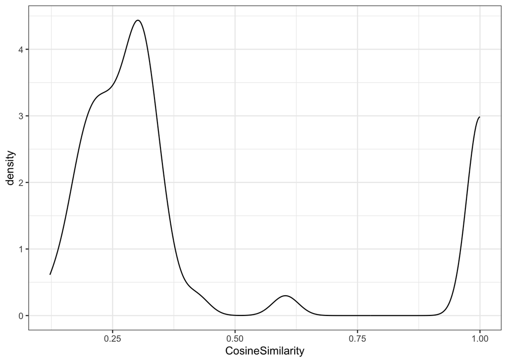

```r
ggplot(d, aes(CosineSimilarity)) +
  geom_density(alpha = .5)
```

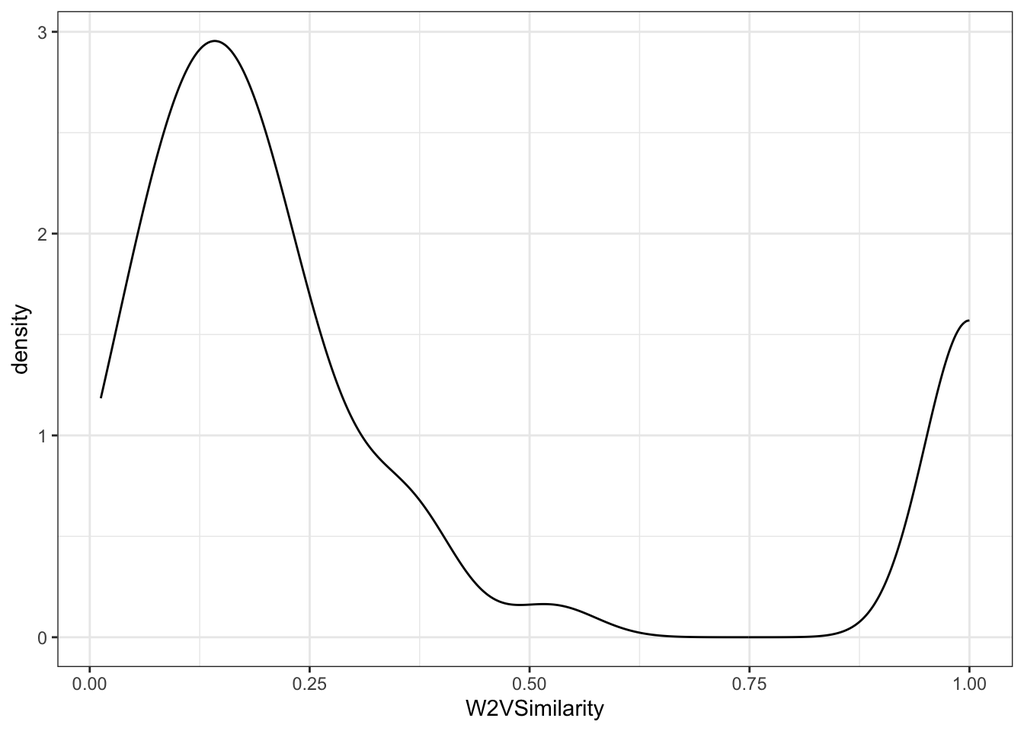

```r
ggplot(d, aes(W2VSimilarity)) +
  geom_density(alpha = .5)
```

```r
names(d)
```

```
## [1] "WordPair"         "X"                "ID.Ibex"          "Response"
## [5] "FeatureMatch"     "Word1"            "Word2"            "W2VSimilarity"
## [9] "CosineSimilarity"
```

```r
dcen <- d %>%
  mutate(WordPair = as.factor(WordPair),
         ID.Ibex = as.factor(ID.Ibex),
         FeatureMatch = as.factor(FeatureMatch),
         cResponse = as.numeric(Response)-mean(as.numeric(Response)))

m <- lmer(cResponse ~ FeatureMatch + (1|WordPair) + (1+FeatureMatch|ID.Ibex), data = dcen)
```

```
## boundary (singular) fit: see help('isSingular')
```

```r
summary(m)
```

```
## Linear mixed model fit by REML. t-tests use Satterthwaite's method [
## lmerModLmerTest]
## Formula: cResponse ~ FeatureMatch + (1 | WordPair) + (1 + FeatureMatch |
##     ID.Ibex)
##    Data: dcen
##
## REML criterion at convergence: 4207.9
##
## Scaled residuals:
##     Min      1Q  Median      3Q     Max
## -5.9320 -0.3450 -0.0430  0.0749  4.1501
##
## Random effects:
##  Groups   Name                            Variance Std.Dev. Corr
##  WordPair (Intercept)                     195.097  13.968
##  ID.Ibex  (Intercept)                       7.150   2.674
##           FeatureMatchMaxMatch             34.610   5.883    0.23
##           FeatureMatchMaxMismatch           9.193   3.032   -1.00 -0.24
##           FeatureMatchSelfPair              5.419   2.328   -0.91  0.09  0.91
##           FeatureMatchValenceMatchingOnly  21.420   4.628    0.19  0.94 -0.19
##  Residual                                 215.433  14.678
##
##
##
##
##
##
##   0.21
##
## Number of obs: 500, groups:  WordPair, 50; ID.Ibex, 10
##
## Fixed effects:
##                                 Estimate Std. Error      df t value Pr(>|t|)
## (Intercept)                      -22.330      4.731  44.072  -4.720 2.41e-05
## FeatureMatchMaxMatch              17.720      6.840  45.178   2.591   0.0129
## FeatureMatchMaxMismatch           -3.110      6.652  44.944  -0.468   0.6424
## FeatureMatchSelfPair              92.390      6.623  44.530  13.949  < 2e-16
## FeatureMatchValenceMatchingOnly    4.650      6.743  44.610   0.690   0.4940
##
## (Intercept)                     ***
## FeatureMatchMaxMatch            *
## FeatureMatchMaxMismatch
## FeatureMatchSelfPair            ***
## FeatureMatchValenceMatchingOnly
## ---
## Signif. codes:  0 '***' 0.001 '**' 0.01 '*' 0.05 '.' 0.1 ' ' 1
##
## Correlation of Fixed Effects:
##             (Intr) FtrMtchMxMt FtrMtchMxMs FtrMSP
## FtrMtchMxMt -0.658
## FtrMtchMxMs -0.714  0.467
## FtrMtchSlfP -0.710  0.481       0.506
## FtrMtchVlMO -0.672  0.525       0.477       0.490
## optimizer (nloptwrap) convergence code: 0 (OK)
## boundary (singular) fit: see help('isSingular')
```

### Plot fixed effect estimates with confidence intervals

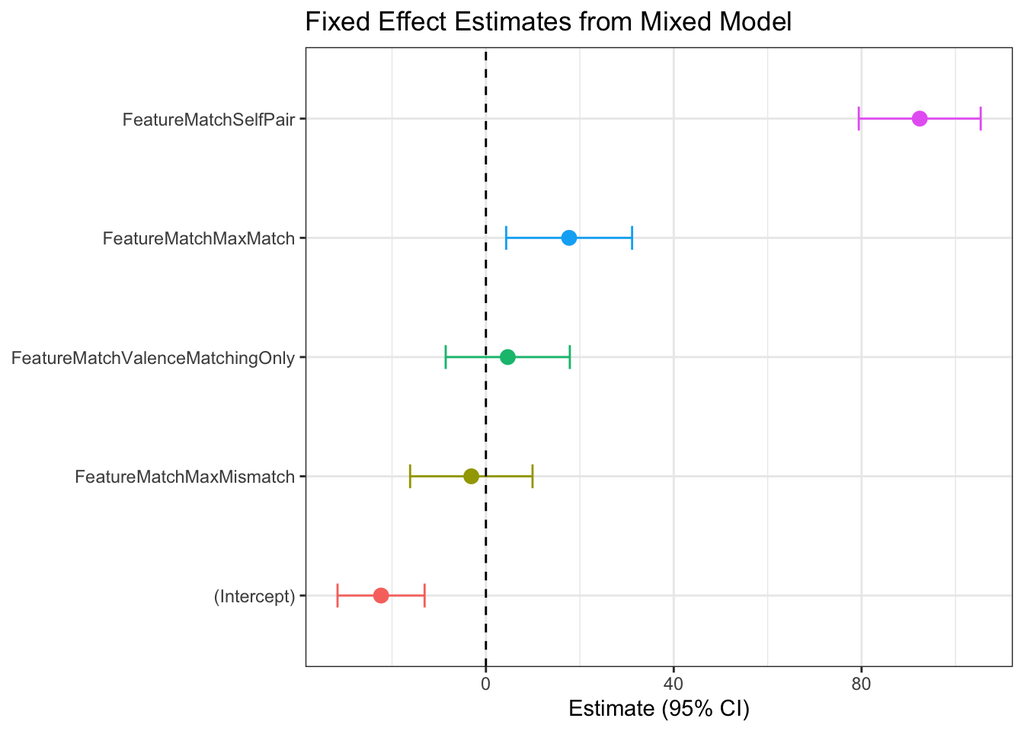

```r
# Tidy the model output
coefs <- tidy(m, effects = "fixed")
# Reorder by effect size for prettier plotting
coefs$term <- factor(coefs$term, levels = coefs$term[order(coefs$estimate)])

# Then replot
ggplot(coefs, aes(x = estimate, y = term, color = term)) +
  geom_point(size = 3) +
  geom_errorbarh(aes(xmin = estimate - 1.96 * std.error,
                     xmax = estimate + 1.96 * std.error), height = 0.2) +
  geom_vline(xintercept = 0, linetype = "dashed") +
  # theme_minimal(base_size = 14) +
  labs(title = "Fixed Effect Estimates from Mixed Model",
       x = "Estimate (95% CI)", y = NULL) +
  theme(legend.position="none")
```

### Plot predicted values vs. predictors

You can create a dataset of predicted values from your model and plot how the response changes with predictors:

```r
newdata <- expand.grid(
  FeatureMatch = levels(dcen$FeatureMatch))
```

2. Get predicted values and standard errors from the model

```r
pred <- predict(m, newdata = newdata, re.form = NA, se.fit = TRUE)
```

3. Add predictions and confidence intervals to newdata

```r
newdata$fit <- pred$fit
newdata$se <- pred$se.fit
newdata <- newdata %>%
  mutate(
    conf.low = fit - 1.96 * se,
    conf.high = fit + 1.96 * se
  )
```

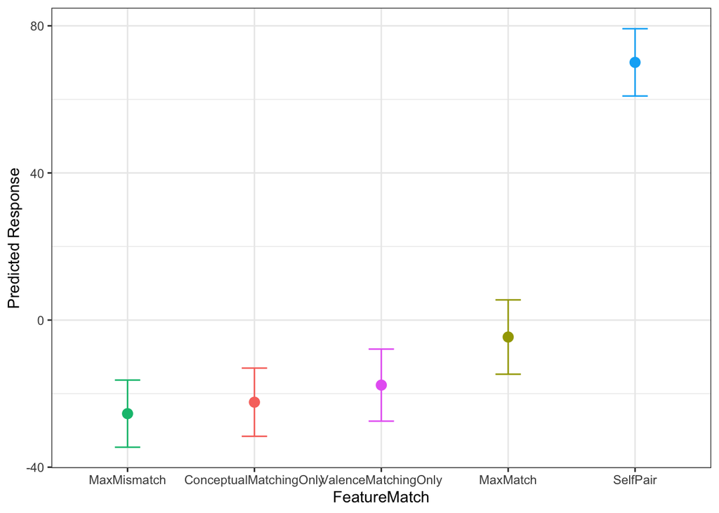

```r
ggplot(newdata, aes(x = reorder(FeatureMatch,fit), y = fit, color = FeatureMatch, fill = FeatureMatch)) +
  geom_point(size = 3) +
  geom_errorbar(aes(ymin = conf.low, ymax = conf.high), width = 0.2) +
  # theme_minimal() +
  labs(x = "FeatureMatch", y = "Predicted Response", color = "FeatureMatch", fill = "FeatureMatch") +
  theme(legend.position="none")
```

## You can visualize individual random effect estimates:

What you get from the plot: A visual summary of the variability in random effects across levels of your grouping factors.

Helps you identify:

Which groups (subjects/items) deviate strongly from the average effect,

How precise these deviations are,

Whether there are outliers or patterns in random effects.

Example interpretation: If a subject’s random intercept dot is far from zero with narrow error bars, that subject consistently differs from the average intercept with high certainty.

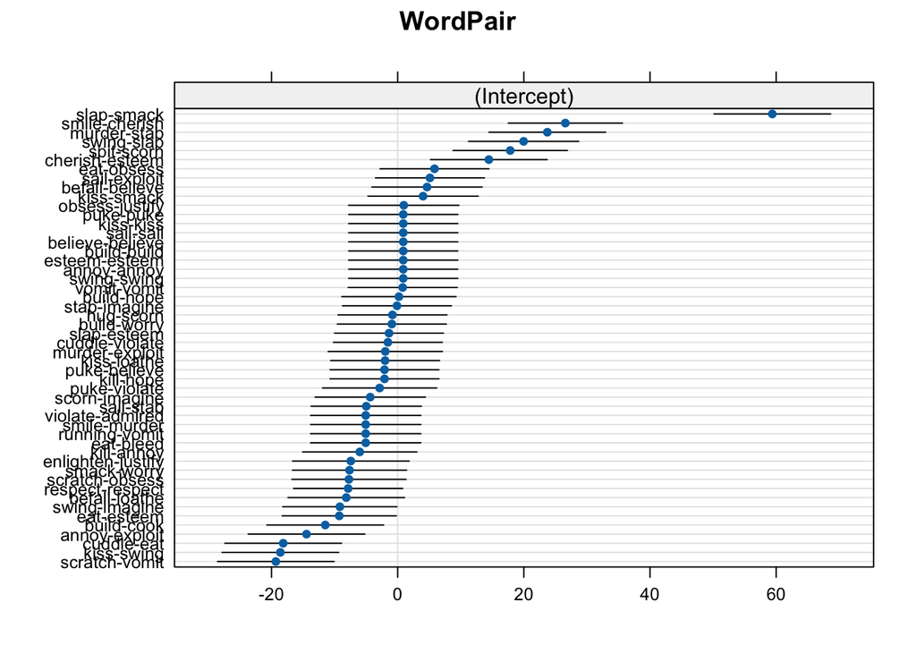

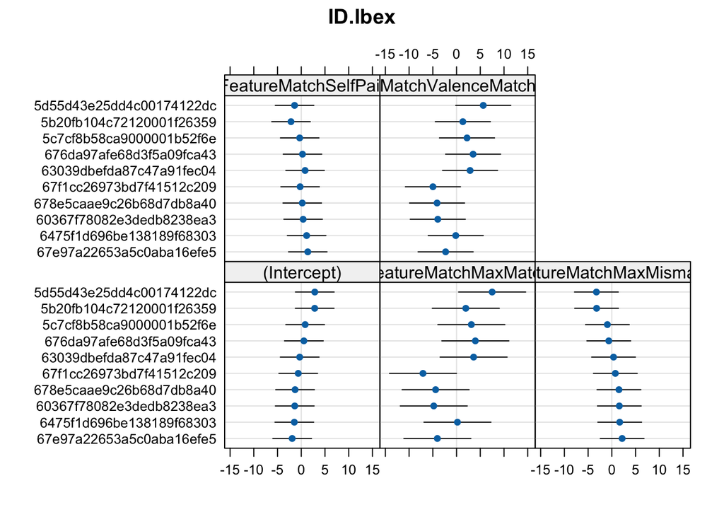

```r
dotplot(ranef(m, condVar=TRUE))
```

## Check model diagnostics

For residuals, fitted vs residuals, etc.:

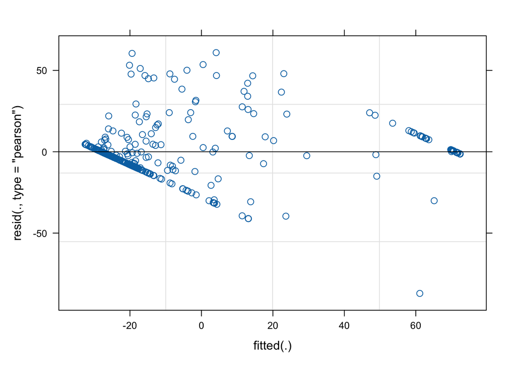

```r
plot(m)
```

# Does Similarity predict or interact with FeatureMatch?

## Cosine Similarity from Transformer Models

```r
m.full <- lmer(cResponse ~ FeatureMatch*CosineSimilarity + (1|WordPair) + (1|ID.Ibex), data = dcen)
```

```
## fixed-effect model matrix is rank deficient so dropping 1 column / coefficient
```

```r
summary(m.full)
```

```
## Linear mixed model fit by REML. t-tests use Satterthwaite's method [
## lmerModLmerTest]
## Formula: cResponse ~ FeatureMatch * CosineSimilarity + (1 | WordPair) +
##     (1 | ID.Ibex)
##    Data: dcen
##
## REML criterion at convergence: 4156.1
##
## Scaled residuals:
##     Min      1Q  Median      3Q     Max
## -5.7058 -0.3471 -0.0792  0.1105  4.1502
##
## Random effects:
##  Groups   Name        Variance Std.Dev.
##  WordPair (Intercept) 109.702  10.474
##  ID.Ibex  (Intercept)   7.666   2.769
##  Residual             225.823  15.027
## Number of obs: 500, groups:  WordPair, 50; ID.Ibex, 10
##
## Fixed effects:
##                                                  Estimate Std. Error     df
## (Intercept)                                        -45.17      18.31  41.19
## FeatureMatchMaxMatch                               -13.34      21.05  41.00
## FeatureMatchMaxMismatch                             18.77      24.72  41.00
## FeatureMatchSelfPair                                34.29      45.89  41.00
## FeatureMatchValenceMatchingOnly                     17.46      23.34  41.00
## CosineSimilarity                                    80.94      63.52  41.00
## FeatureMatchMaxMatch:CosineSimilarity               89.60      70.63  41.00
## FeatureMatchMaxMismatch:CosineSimilarity           -77.10      91.00  41.00
## FeatureMatchValenceMatchingOnly:CosineSimilarity   -40.46      85.10  41.00
##                                                  t value Pr(>|t|)
## (Intercept)                                       -2.467   0.0179 *
## FeatureMatchMaxMatch                              -0.634   0.5296
## FeatureMatchMaxMismatch                            0.759   0.4519
## FeatureMatchSelfPair                               0.747   0.4592
## FeatureMatchValenceMatchingOnly                    0.748   0.4588
## CosineSimilarity                                   1.274   0.2098
## FeatureMatchMaxMatch:CosineSimilarity              1.269   0.2117
## FeatureMatchMaxMismatch:CosineSimilarity          -0.847   0.4018
## FeatureMatchValenceMatchingOnly:CosineSimilarity  -0.475   0.6370
```

[output cut: 9 more lines]

```
## CosinSmlrty    -0.979  0.852       0.725      -0.994  0.768
## FtrMtchMxMt:CS  0.880 -0.969      -0.652       0.894 -0.691 -0.899
## FtrMtchMxMs:CS  0.683 -0.594      -0.976       0.694 -0.536 -0.698
## FtrMtVMO:CS     0.731 -0.636      -0.541       0.742 -0.973 -0.746
##                FtrMtchMxMt:CS FtrMtchMxMs:CS
## FtrMtchMxMt
## FtrMtchMxMs
## FtrMtchSlfP
## FtrMtchVlMO
## CosinSmlrty
## FtrMtchMxMt:CS
## FtrMtchMxMs:CS  0.628
## FtrMtVMO:CS     0.671          0.521
## fit warnings:
## fixed-effect model matrix is rank deficient so dropping 1 column / coefficient
```

## Does adding Cosine Similarity explain any more variance in the data?

```r
m.s <- lmer(cResponse ~ FeatureMatch + (1|WordPair) + (1|ID.Ibex), data = dcen)

anova(m.s, m.full, REML=FALSE)
```

```
## refitting model(s) with ML (instead of REML)
```

```
## Data: dcen
## Models:
## m.s: cResponse ~ FeatureMatch + (1 | WordPair) + (1 | ID.Ibex)
## m.full: cResponse ~ FeatureMatch * CosineSimilarity + (1 | WordPair) + (1 | ID.Ibex)
##        npar    AIC    BIC  logLik deviance  Chisq Df Pr(>Chisq)
## m.s       8 4261.7 4295.4 -2122.8   4245.7
## m.full   12 4240.5 4291.1 -2108.2   4216.5 29.178  4  7.192e-06 ***
## ---
## Signif. codes:  0 '***' 0.001 '**' 0.01 '*' 0.05 '.' 0.1 ' ' 1
```

### Plot fixed effect estimates with confidence intervals

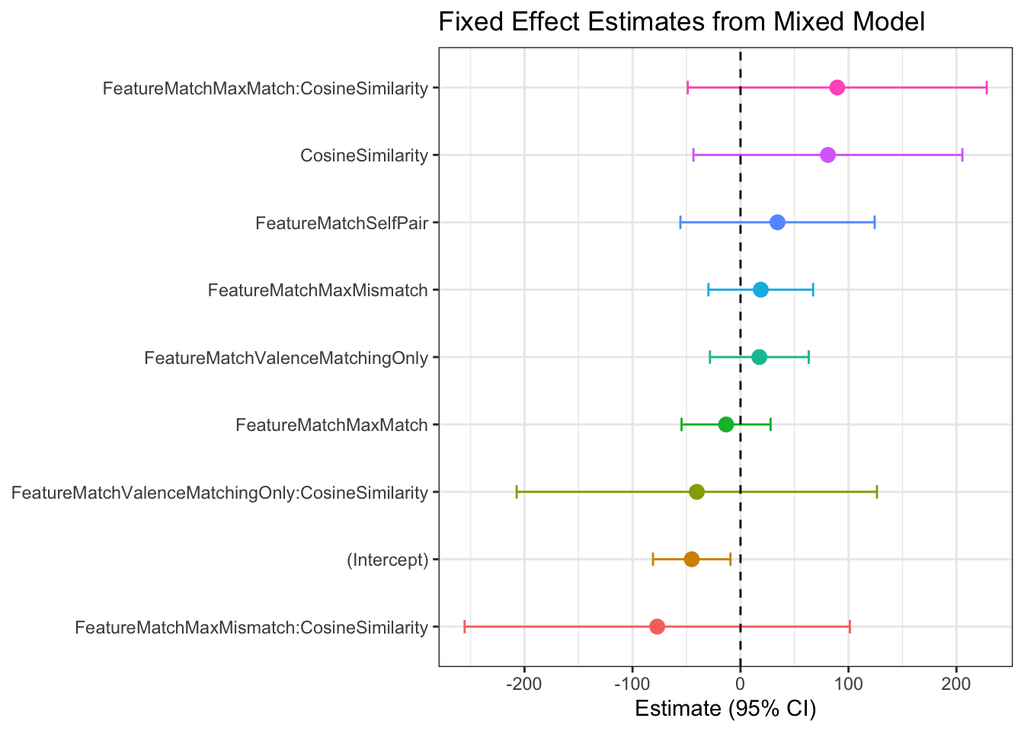

```r
# Tidy the model output
coefs <- tidy(m.full, effects = "fixed")

# Reorder by effect size for prettier plotting
coefs$term <- factor(coefs$term, levels = coefs$term[order(coefs$estimate)])

# Then replot
ggplot(coefs, aes(x = estimate, y = term, color = term)) +
  geom_point(size = 3) +
  geom_errorbarh(aes(xmin = estimate - 1.96 * std.error,
                     xmax = estimate + 1.96 * std.error), height = 0.2) +
  geom_vline(xintercept = 0, linetype = "dashed") +
  # theme_minimal(base_size = 14) +
  labs(title = "Fixed Effect Estimates from Mixed Model",
       x = "Estimate (95% CI)", y = NULL) +
  theme(legend.position="none")
```

## Word-2-Vec Similarity

```r
m.full <- lmer(cResponse ~ FeatureMatch*W2VSimilarity + (1|WordPair) + (1|ID.Ibex), data = dcen)
```

```
## fixed-effect model matrix is rank deficient so dropping 1 column / coefficient
```

```r
summary(m.full)
```

```
## Linear mixed model fit by REML. t-tests use Satterthwaite's method [
## lmerModLmerTest]
## Formula: cResponse ~ FeatureMatch * W2VSimilarity + (1 | WordPair) + (1 |
##     ID.Ibex)
##    Data: dcen
##
## REML criterion at convergence: 4154.9
##
## Scaled residuals:
##     Min      1Q  Median      3Q     Max
## -5.7157 -0.3311 -0.0746  0.1029  4.1058
##
## Random effects:
##  Groups   Name        Variance Std.Dev.
##  WordPair (Intercept)  97.693   9.884
##  ID.Ibex  (Intercept)   7.664   2.768
##  Residual             225.825  15.027
## Number of obs: 500, groups:  WordPair, 50; ID.Ibex, 10
##
## Fixed effects:
##                                               Estimate Std. Error       df
## (Intercept)                                   -27.5511     8.0880  41.9122
## FeatureMatchMaxMatch                          -20.6883    11.3489  41.0023
## FeatureMatchMaxMismatch                        -0.5903    10.1236  41.0023
## FeatureMatchSelfPair                           62.9570    41.1864  41.0023
## FeatureMatchValenceMatchingOnly                 1.5699    10.1127  41.0023
## W2VSimilarity                                  34.6541    48.1474  41.0023
## FeatureMatchMaxMatch:W2VSimilarity            138.9711    56.0678  41.0023
## FeatureMatchMaxMismatch:W2VSimilarity         -16.1728    59.3820  41.0023
## FeatureMatchValenceMatchingOnly:W2VSimilarity  18.6533    58.0812  41.0023
##                                               t value Pr(>|t|)
## (Intercept)                                    -3.406  0.00146 **
## FeatureMatchMaxMatch                           -1.823  0.07561 .
## FeatureMatchMaxMismatch                        -0.058  0.95379
## FeatureMatchSelfPair                            1.529  0.13405
## FeatureMatchValenceMatchingOnly                 0.155  0.87739
## W2VSimilarity                                   0.720  0.47576
## FeatureMatchMaxMatch:W2VSimilarity              2.479  0.01739 *
## FeatureMatchMaxMismatch:W2VSimilarity          -0.272  0.78672
## FeatureMatchValenceMatchingOnly:W2VSimilarity   0.321  0.74972
```

[output cut: 9 more lines]

```
## W2VSimilrty      -0.897  0.639       0.717      -0.993  0.717
## FtrMtchMxMt:W2VS  0.770 -0.875      -0.615       0.853 -0.616 -0.859
## FtrMtchMxMs:W2VS  0.727 -0.518      -0.875       0.805 -0.582 -0.811
## FtMVMO:W2VS       0.743 -0.530      -0.594       0.823 -0.874 -0.829
##                  FtrMtchMxMt:W2VS FtrMtchMxMs:W2VS
## FtrMtchMxMt
## FtrMtchMxMs
## FtrMtchSlfP
## FtrMtchVlMO
## W2VSimilrty
## FtrMtchMxMt:W2VS
## FtrMtchMxMs:W2VS  0.696
## FtMVMO:W2VS       0.712            0.672
## fit warnings:
## fixed-effect model matrix is rank deficient so dropping 1 column / coefficient
```

```r
m.s <- lmer(cResponse ~ FeatureMatch + (1|WordPair) + (1|ID.Ibex), data = dcen)
```

## Does adding Word-2-Vec Similarity explain any more variance in the data?

- Yes

```r
anova(m.s, m.full, REML=FALSE)
```

```
## refitting model(s) with ML (instead of REML)
```

```
## Data: dcen
## Models:
## m.s: cResponse ~ FeatureMatch + (1 | WordPair) + (1 | ID.Ibex)
## m.full: cResponse ~ FeatureMatch * W2VSimilarity + (1 | WordPair) + (1 | ID.Ibex)
##        npar    AIC    BIC  logLik deviance  Chisq Df Pr(>Chisq)
## m.s       8 4261.7 4295.4 -2122.8   4245.7
## m.full   12 4235.8 4286.3 -2105.9   4211.8 33.911  4  7.773e-07 ***
## ---
## Signif. codes:  0 '***' 0.001 '**' 0.01 '*' 0.05 '.' 0.1 ' ' 1
```

### Plot fixed effect estimates with confidence intervals

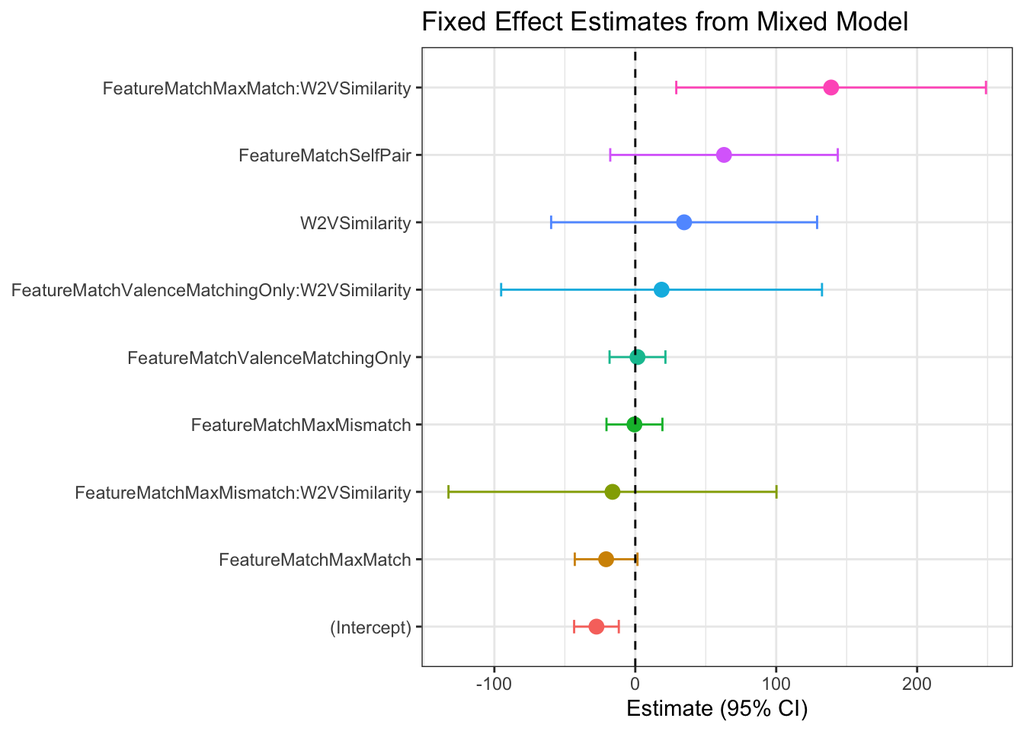

```r
# Tidy the model output
coefs <- tidy(m.full, effects = "fixed")

# Reorder by effect size for prettier plotting
coefs$term <- factor(coefs$term, levels = coefs$term[order(coefs$estimate)])

# Then replot
ggplot(coefs, aes(x = estimate, y = term, color = term)) +
  geom_point(size = 3) +
  geom_errorbarh(aes(xmin = estimate - 1.96 * std.error,
                     xmax = estimate + 1.96 * std.error), height = 0.2) +
  geom_vline(xintercept = 0, linetype = "dashed") +
  # theme_minimal(base_size = 14) +
  labs(title = "Fixed Effect Estimates from Mixed Model",
       x = "Estimate (95% CI)", y = NULL) +
  theme(legend.position="none")
```

### Plot predicted values vs. predictors

You can create a dataset of predicted values from your model and plot how the response changes with predictors:

1. Create a new dataset with combinations of predictors
- Generates all combinations of levels of FeatureMatch (a factor) and a sequence of W2VSimilarity values from -0.01 to 1 (100 points).
- Because: You want to predict your response across a continuous range of W2VSimilarity for each FeatureMatch group.

```r
newdata <- expand.grid(
  FeatureMatch = levels(dcen$FeatureMatch),
  W2VSimilarity = seq(-0.01, 1, length.out = 100)
)
```

2. Get predicted values and standard errors from the model

```r
pred <- predict(m.full, newdata = newdata, re.form = NA, se.fit = TRUE)
```

3. Add predictions and confidence intervals to newdata

```r
newdata$fit <- pred$fit
newdata$se <- pred$se.fit
newdata <- newdata %>%
  mutate(
    conf.low = fit - 1.96 * se,
    conf.high = fit + 1.96 * se
  )
```

4. Plot predicted lines with ribbons for confidence intervals

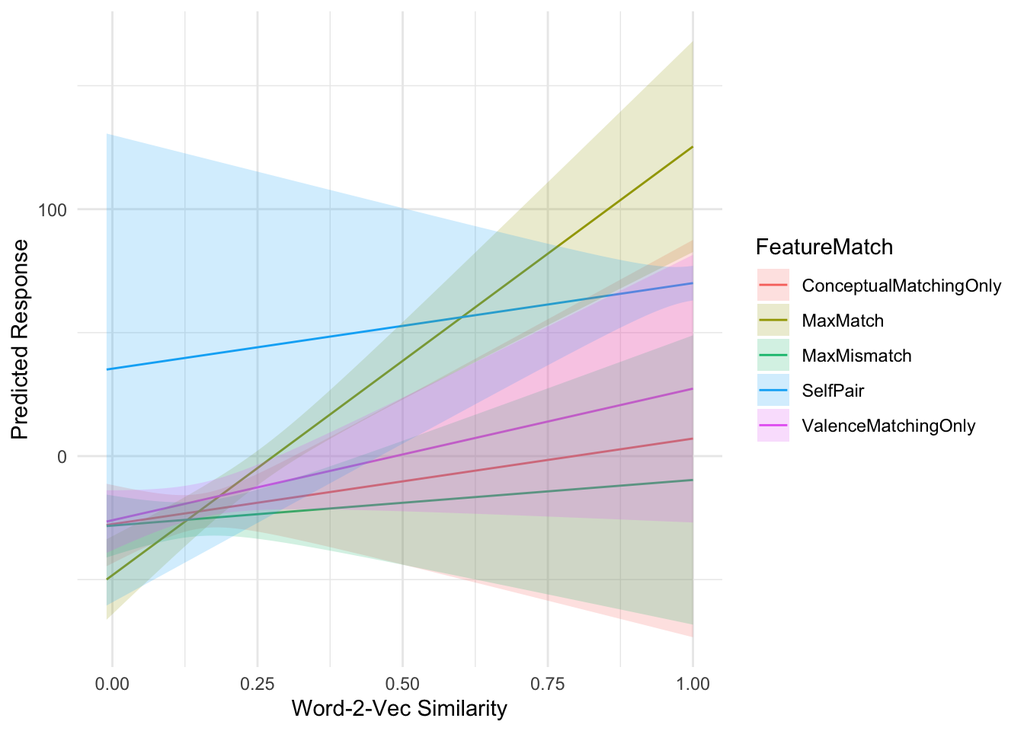

```r
ggplot(newdata, aes(x = W2VSimilarity, y = fit, color = FeatureMatch, fill = FeatureMatch)) +
  geom_line() +
  geom_ribbon(aes(ymin = conf.low, ymax = conf.high), alpha = 0.2, color = NA) +
  theme_minimal() +
  labs(x = "Word-2-Vec Similarity", y = "Predicted Response", color = "FeatureMatch", fill = "FeatureMatch")
```

### Visualize individual random effect estimates:

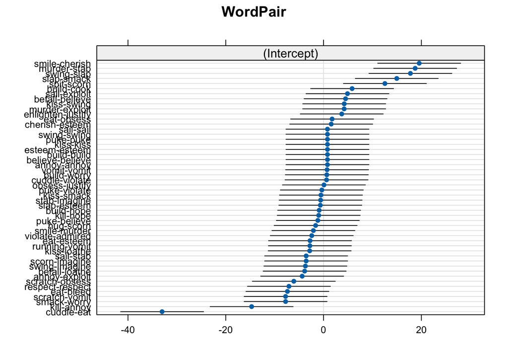

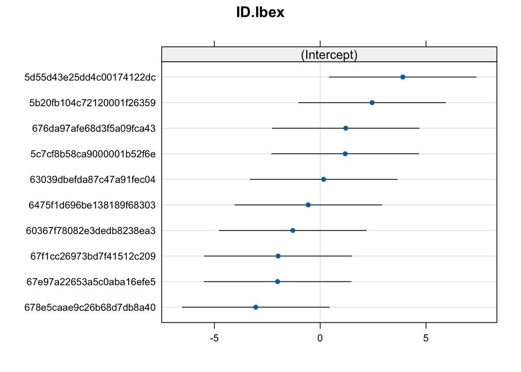

```r
dotplot(ranef(m.full, condVar=TRUE))
```

### Check model diagnostics

For residuals, fitted vs residuals, etc.:

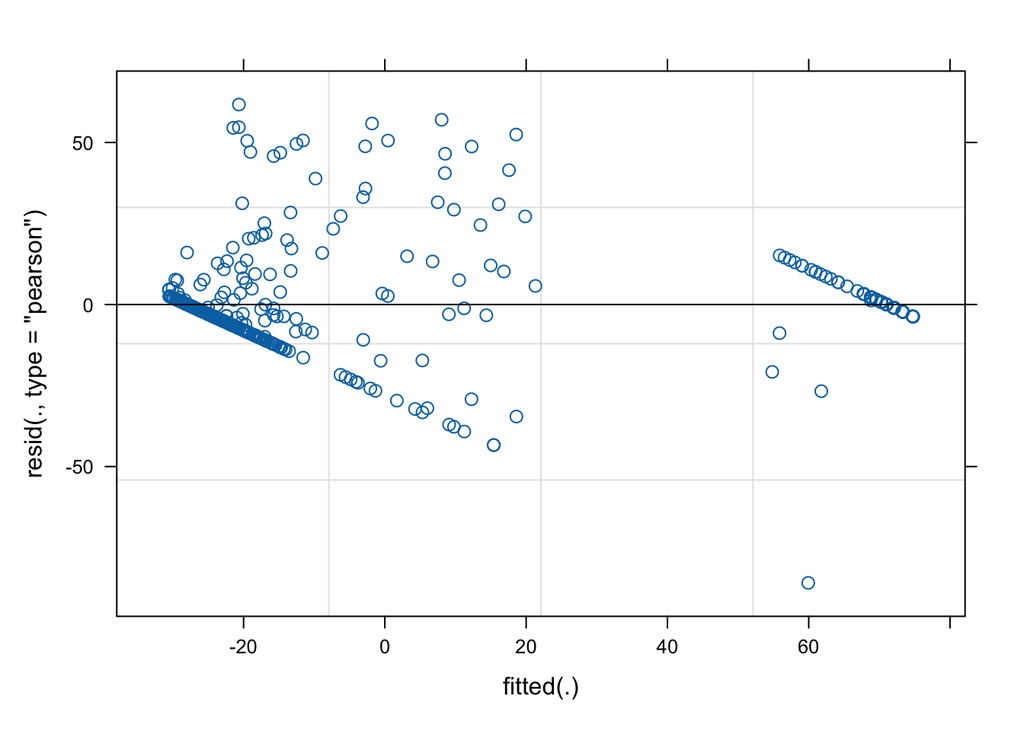

```r
plot(m.full)
```

# Similarity Alone

```r
m <- lmer(cResponse ~ W2VSimilarity + (1|WordPair) + (1|ID.Ibex), data = dcen)
summary(m)
```

```
## Linear mixed model fit by REML. t-tests use Satterthwaite's method [
## lmerModLmerTest]
## Formula: cResponse ~ W2VSimilarity + (1 | WordPair) + (1 | ID.Ibex)
##    Data: dcen
##
## REML criterion at convergence: 4224.3
##
## Scaled residuals:
##     Min      1Q  Median      3Q     Max
## -5.6869 -0.3423 -0.0720  0.1454  3.8879
##
## Random effects:
##  Groups   Name        Variance Std.Dev.
##  WordPair (Intercept) 133.561  11.557
##  ID.Ibex  (Intercept)   7.666   2.769
##  Residual             225.823  15.027
## Number of obs: 500, groups:  WordPair, 50; ID.Ibex, 10
##
## Fixed effects:
##               Estimate Std. Error      df t value Pr(>|t|)
## (Intercept)    -36.018      2.637  50.218  -13.66   <2e-16 ***
## W2VSimilarity  105.695      5.136  48.001   20.58   <2e-16 ***
## ---
## Signif. codes:  0 '***' 0.001 '**' 0.01 '*' 0.05 '.' 0.1 ' ' 1
##
## Correlation of Fixed Effects:
##             (Intr)
## W2VSimilrty -0.664
```

```r
m <- lmer(cResponse ~ CosineSimilarity + (1|WordPair) + (1|ID.Ibex), data = dcen)
summary(m)
```

```
## Linear mixed model fit by REML. t-tests use Satterthwaite's method [
## lmerModLmerTest]
## Formula: cResponse ~ CosineSimilarity + (1 | WordPair) + (1 | ID.Ibex)
##    Data: dcen
##
## REML criterion at convergence: 4225.9
##
## Scaled residuals:
##     Min      1Q  Median      3Q     Max
## -5.6898 -0.3432 -0.0959  0.1069  4.1020
##
## Random effects:
##  Groups   Name        Variance Std.Dev.
##  WordPair (Intercept) 139.726  11.821
##  ID.Ibex  (Intercept)   7.666   2.769
##  Residual             225.823  15.027
## Number of obs: 500, groups:  WordPair, 50; ID.Ibex, 10
##
## Fixed effects:
##                  Estimate Std. Error      df t value Pr(>|t|)
## (Intercept)       -50.710      3.218  51.533  -15.76   <2e-16 ***
## CosineSimilarity  121.024      6.009  48.000   20.14   <2e-16 ***
## ---
## Signif. codes:  0 '***' 0.001 '**' 0.01 '*' 0.05 '.' 0.1 ' ' 1
##
## Correlation of Fixed Effects:
##             (Intr)
## CosinSmlrty -0.783
```